# Reproducible Research: Peer Assessment 1

## Loading and preprocessing the data

1. Download and unzip the dataset

```r
#make code visible
echo = TRUE
#set up directory for graphs
knitr::opts_chunk$set(fig.path='figure/')

fileUrl <- "http://d396qusza40orc.cloudfront.net/repdata%2Fdata%2Factivity.zip"
destFile <- "repdata_data_activity.zip"
download.file(fileUrl, destFile, method = "auto", quiet = T)
unzip(destFile)
```

2. Load data to a data frame

```r
dataFrame <- read.csv("activity.csv", na.strings = "NA")
dataFrame$date <- as.Date(dataFrame$date)
```

## What is mean total number of steps taken per day?

1. Calculate the total number of steps taken per day

```r
stepsPerDay <- aggregate(list(steps = dataFrame$steps), list(date = dataFrame$date), sum)
```

2. Make a histogram of the total number of steps taken each day

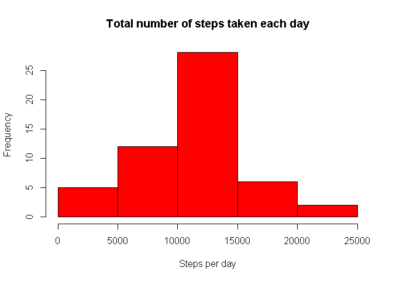

```r
hist(stepsPerDay$steps,
     col = "red",
     main = "Total number of steps taken each day",
     xlab = "Steps per day"
     )
```

3. Calculate and report the mean and median of the total number of steps taken per day

Mean of the total number of steps taken per day:

```r
mean(stepsPerDay$steps, na.rm = T)
```

```
## [1] 10766.19
```

Median of the total number of steps taken per day

```r
median(stepsPerDay$steps, na.rm = T)
```

```
## [1] 10765
```

## What is the average daily activity pattern?

1. Make a time series plot of the 5-minute interval (x-axis) and the average number of steps taken, averaged across all days (y-axis)

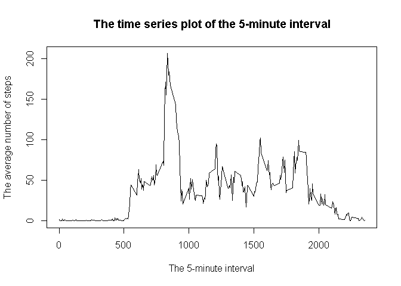

```r
stepsByInterval <- aggregate(steps ~ interval, dataFrame, mean, na.action = na.omit)

plot(stepsByInterval$interval, stepsByInterval$steps,
     type="l",
     main="The time series plot of the 5-minute interval",
     xlab="The 5-minute interval",
     ylab="The average number of steps"
     )
```

2. Which 5-minute interval, on average across all the days in the dataset, contains the maximum number of steps?

```r
as.numeric(stepsByInterval[stepsByInterval$steps == max(stepsByInterval$steps),][1])
```

```
## [1] 835
```